# Lecture 7

24 February 2020

## Structure

1.) Customer churn  
2.) Decission trees  
3.) Boosting and Bagging  
4.) Random forests

## Customer churn

## What is churn?

- customer attrition
- loss of clients
- targetted mostly by
  - banks, insurance companies
  - telcom, intenet, TV providers
- mostly service companies
- cheeper to retain customers than to find new ones

## Much ado churn?

- Why do those companies care so much?
  - customers ~ free money
- financial institutions
  - you keep your customers money
- communication & TV
  - customer pays every month
- service providers with high initial (fixed) costs and very low variable costs
  - how much are the actuall costs of transfering 1 GB of data?
  - how much are the costs of providing insurance to customer?

## Churn types

- explicit (contractual) vs. implicit (non-contractual)
- voluntary (pro-active) vs. involuntary (reactive)
- happy churn
- fake churn

## Decission trees

## Introduction to decission rules

- if-else conditions used to split data
- aimed at increasing “purity”
  - InfoGain / Gini
  - decrease of variation
- if build hierarchically, they form a tree

## Tree types

- rpart
  - recursive partitioning
  - both classification / regression
  - Gini
- C.5
  - only classification
  - InfoGain
- CHAID
- MARS

## Gini coefficient

- first we label the observation randomly
  - with regard to the original proportions in the data
- we choose observation randomly
- what is the probability it is incorrectly classified?

\[G(p) = \sum_{i=1}^{J}p_{i} \sum_{k \neq i}p_{k} = \sum_{i=1}^{J}p_{i}*(1-p_{i}) = \sum_{i=1}^{J}p_{i} - \sum_{i=1}^{J}p_{i}^{2}\]

## Entropy function

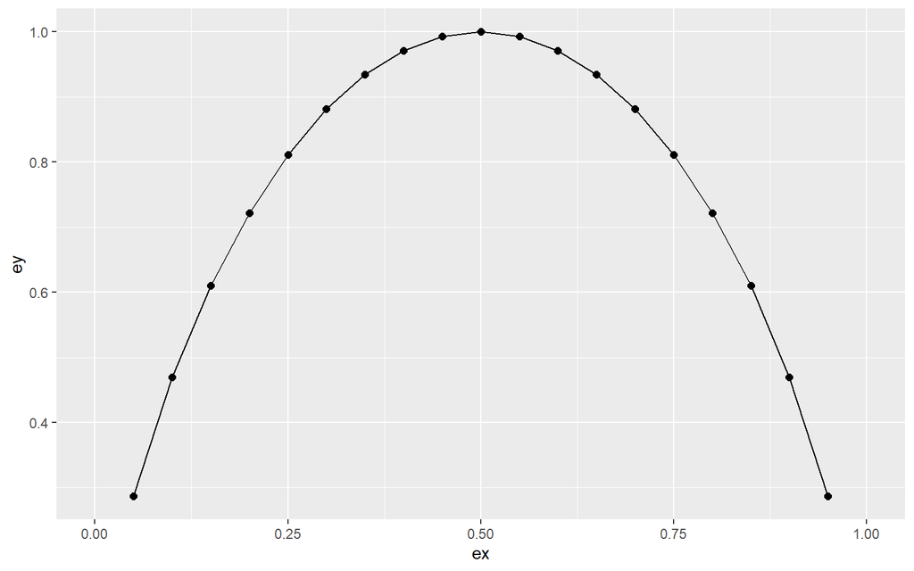

## Entropy & InfoGain

- information entropy

\[E = -\sum_{i=1}^{J}p_{i}log_{2}p_{i}\]

- information gain

\[IG_{k} = E_{k-1} - \sum_{s}^{S}\frac{n_{s}}{n}E_{s}\]

## MARS

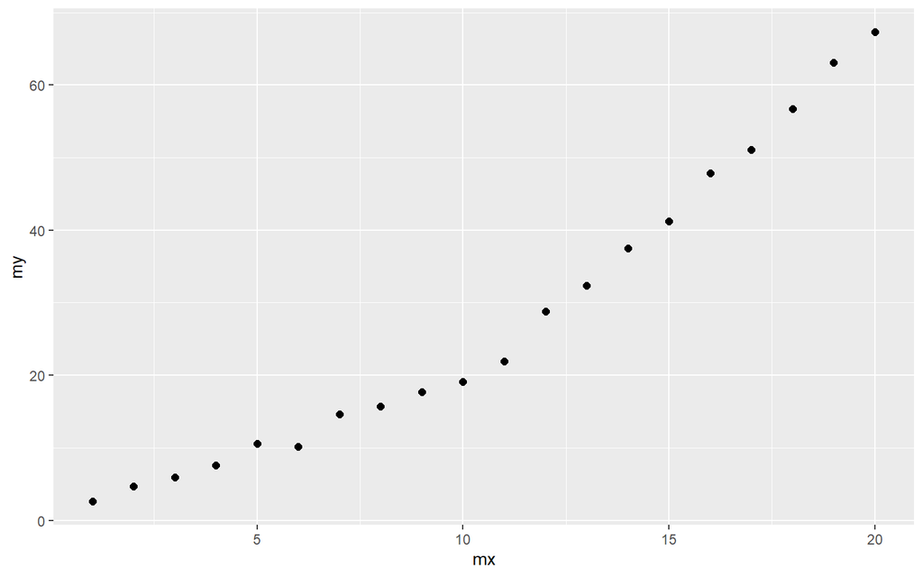

## MARS - linear model

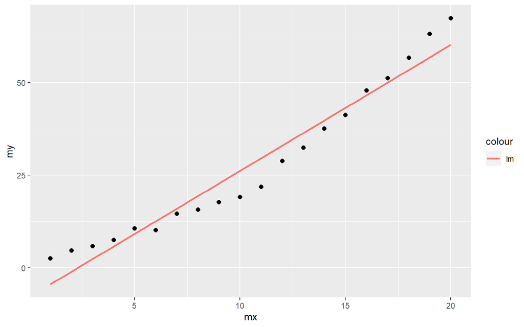

## MARS - mars model

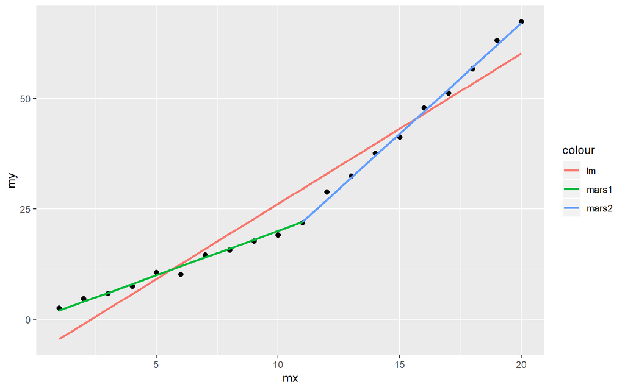

## MARS

- multivariate adaptive regression splines
- fitting several linear models

\[\hat y = 22 - 2 * max(0, 11 - x) + 5 * max(0, x-11)\]

\[\hat f(x) = \sum_{i}^{k} c_{i}B_{i}(x)\]

- basis function \(B_{i}(x)\)
  - constant \(1\)
  - hinge function (\(max(0, x - const)\) or \(max(0, const - x)\))
  - product of hinge functions

## Trees

- classification & regression
- very greedy
  - always optimising on one variable only!
- more flexible than linear models
  - can easily handle non-linear relations
  - automatic variable selection
- can’t predict out of scope of the input data
  - can’t be used for time series (on their own)

## Example trees

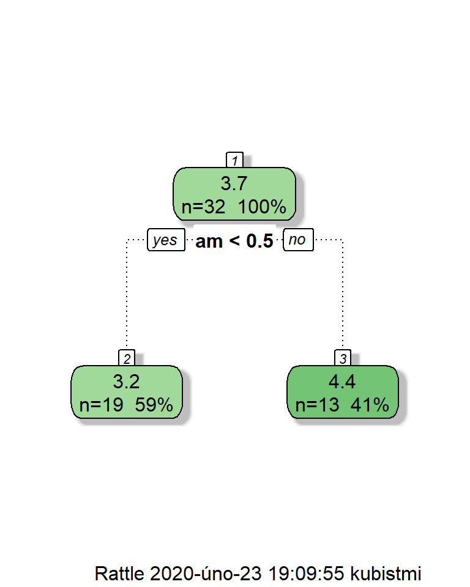

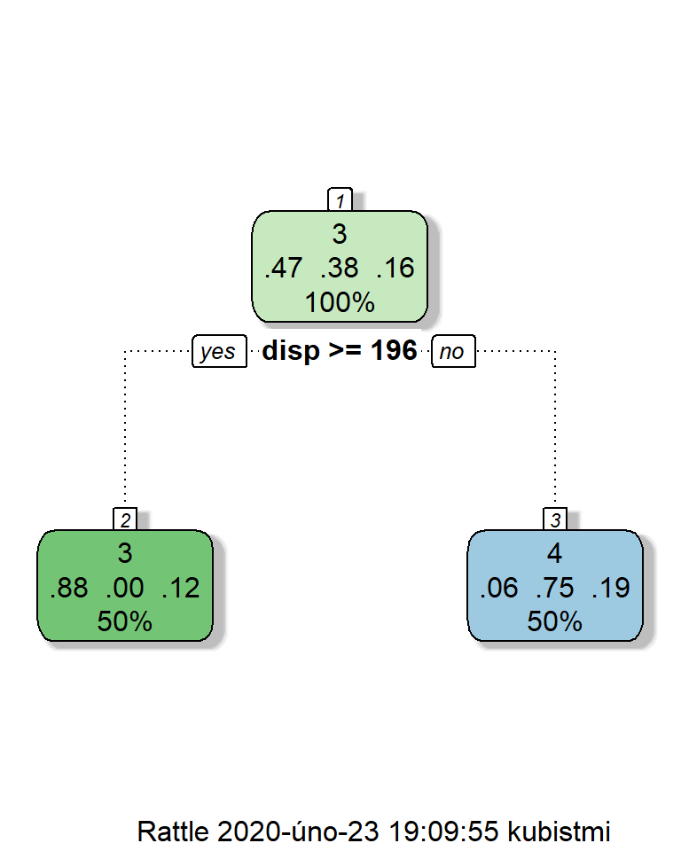

## Summary

- rpart::rpart
- C5O::C5.0.default
- mda::mars
- handle complex relations well
- automatic variable selection
  - good for large datasets
- very greedy
- unstable
  - insufficient for small datasets

## Boosting & Bagging

## Boosting

- ensembling a large number of week learners (models) into one strong
- linear
  - first model
  - second is trained on residuals of the first
  - third is trained on the residuals (of residuals) of the second model
- subsetting observations
  - more weight to missclasiffied ones
- increasing accuracy
  - prone to overfitting

## Bagging

- ensembling a large number of strong learners (models) into one strong
- in parallel
  - independent models
- subsetting observations and variables
  - observations sampled with repetitions
    - one original observation can be used more than one time in each of the models
- increasing stability

## Random forests

## Welcome to the forest

- bagging algorithm
- build from trees
- good accuracy and stability
- black box

## Opening the black box

- variable importance

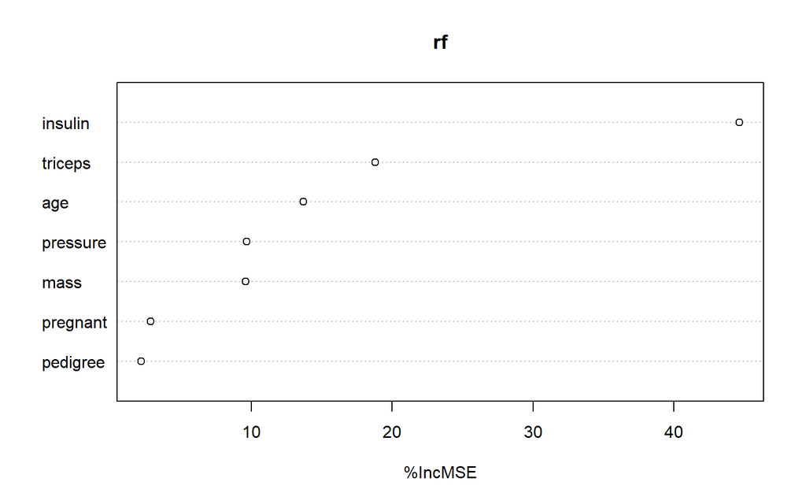

## Opening the black box

- predictions

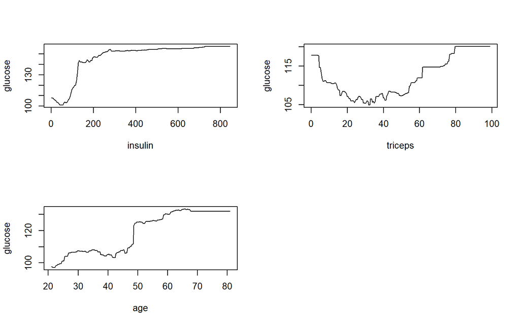

## Opening the black box

- forestFloor

```
## [1] "compute goodness-of-fit with leave-one-out k-nearest neighbor(guassian weighting), kknn package"
```

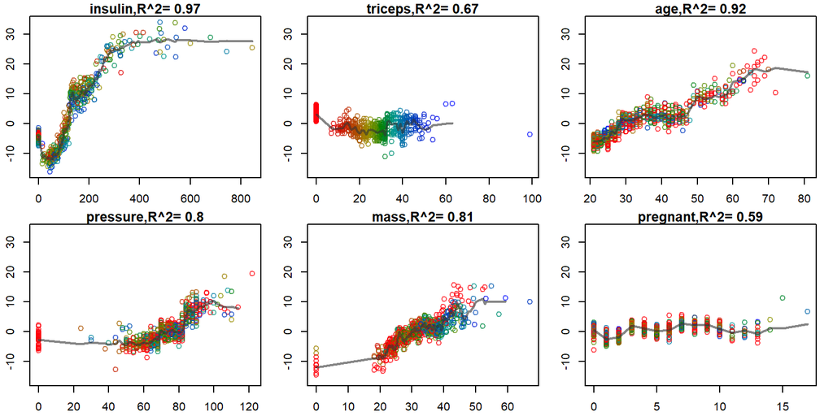

## Opening the black box

- inTrees

| len | freq | err | condition | pred |
| --- | --- | --- | --- | --- |
| 2 | 0.00 | 9.00 | X[,2]<=81 & X[,6]<=0.681 | 77.00 |
| 3 | 0.01 | 141.84 | X[,2]>81 & X[,3]<=5 & X[,6]<=0.681 | 102.40 |
| 2 | 0.04 | 698.25 | X[,3]<=5 & X[,6]>0.681 | 123.46 |
| 1 | 0.03 | 756.67 | X[,2]<=73 | 52.00 |
| 3 | 0.48 | 826.70 | X[,2]>73 & X[,4]<=59.5 & X[,5]<=40.55 | 121.29 |